# PMLCourseProject

Reynold Guerrier

December 25, 2016

## Abstract

This project aim to use HAR Human Activity Recognition data set to make predictions. We will apply machine learning algorithm on 20 test cases available in the given data set to be able to submit our predictions. We decide to use Classification tree, boosting and linear dicriminant and random forest, a subset of the training data to assess tjeir accuracy level.

## Cleaning and Explanatory Data

When checking the training and the testing data sets we find out there is a lot of “NA” and some “DIV/0” that must be stripped out because they will not impact the predictions. Other variables like names, identifiers and time aren’t useful either for our work.

## Cleaning the data sets

Removing some predictors that are not relevant for our observations.

```r
trainData <- training[, -c(1:7)]
testData <- testing[, -c(1:7)]
```

# Data subsetting

```r
set.seed(1234)
inTrain <- createDataPartition(trainData$classe, p = 0.7, list = FALSE)
train <- trainData[inTrain, ]
valid <- trainData[-inTrain, ]
```

## Prediction Algorithms

We will apply some prediction algorithms and we will choose the more accurate for our test data

# Claissification tree

```
## CART
##
## 13737 samples
##    52 predictor
##     5 classes: 'A', 'B', 'C', 'D', 'E'
##
## No pre-processing
## Resampling: Cross-Validated (5 fold)
## Summary of sample sizes: 10990, 10988, 10991, 10990, 10989
## Resampling results across tuning parameters:
##
##   cp       Accuracy  Kappa
##   0.03550  0.5214    0.38010
##   0.06093  0.4175    0.21094
##   0.11738  0.3333    0.07467
##
## Accuracy was used to select the optimal model using  the largest value.
## The final value used for the model was cp = 0.0355.
```

Plotting the tree

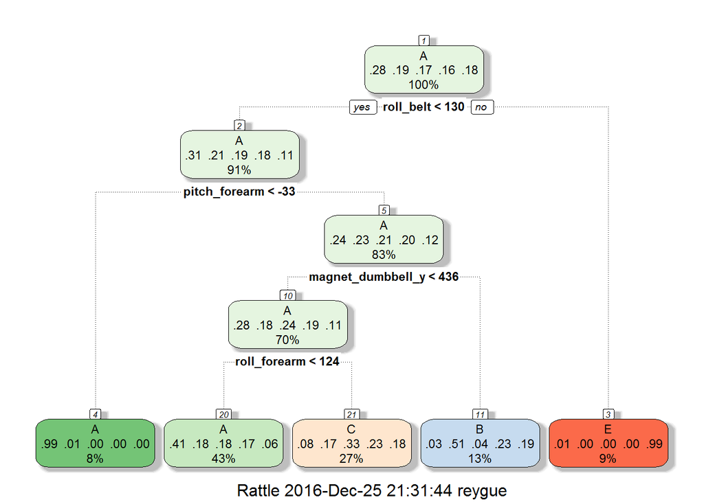

```
## Confusion Matrix and Statistics
##
##           Reference
## Prediction    A    B    C    D    E
##          A 1530   35  105    0    4
##          B  486  379  274    0    0
##          C  493   31  502    0    0
##          D  452  164  348    0    0
##          E  168  145  302    0  467
##
## Overall Statistics
##
##                Accuracy : 0.489
##                  95% CI : (0.4762, 0.5019)
##     No Information Rate : 0.5317
##     P-Value [Acc > NIR] : 1
##
##                   Kappa : 0.3311
##  Mcnemar's Test P-Value : NA
##
## Statistics by Class:
##
##                      Class: A Class: B Class: C Class: D Class: E
## Sensitivity            0.4890   0.5027   0.3279       NA  0.99151
## Specificity            0.9478   0.8519   0.8797   0.8362  0.88641
## Pos Pred Value         0.9140   0.3327   0.4893       NA  0.43161
## Neg Pred Value         0.6203   0.9210   0.7882       NA  0.99917
## Prevalence             0.5317   0.1281   0.2602   0.0000  0.08003
## Detection Rate         0.2600   0.0644   0.0853   0.0000  0.07935
## Detection Prevalence   0.2845   0.1935   0.1743   0.1638  0.18386
## Balanced Accuracy      0.7184   0.6773   0.6038       NA  0.93896
```

# Classification tree accuracy

```r
(accuracy_rpart <- conf_rpart$overall[1])
```

```
##  Accuracy
## 0.4890399
```

## Boosting

Creating the model and predict outcomes using validation set

```r
library(gbm)
fit_gbm <- train(classe ~ ., data = train, method = "gbm")
predgbm <- predict(fit_gbm, valid)
(confgbm <- confusionMatrix(valid$classe, predgbm))
```

[output not shown]

Accuracy

```r
(accuracy_ <- confgbm$overall[1])
```

```
##  Accuracy
## 0.9626168
```

## Linear Discriminant

Creating the model and predict outcomes using validation set

```r
fit_lda <- train(classe ~ ., data = train, method = "lda")
predlda <- predict(fit_lda, valid)
(conflda <- confusionMatrix(valid$classe, predlda))
```

```
## Confusion Matrix and Statistics
##
##           Reference
## Prediction    A    B    C    D    E
##          A 1371   38  146  116    3
##          B  177  735  138   42   47
##          C   91   98  683  126   28
##          D   63   38  114  719   30
##          E   46  192   94  110  640
##
## Overall Statistics
##
##                Accuracy : 0.7048
##                  95% CI : (0.693, 0.7165)
##     No Information Rate : 0.297
##     P-Value [Acc > NIR] : < 2.2e-16
##
##                   Kappa : 0.6265
##  Mcnemar's Test P-Value : < 2.2e-16
##
## Statistics by Class:
##
##                      Class: A Class: B Class: C Class: D Class: E
## Sensitivity            0.7843   0.6676   0.5813   0.6460   0.8556
## Specificity            0.9268   0.9156   0.9272   0.9487   0.9140
## Pos Pred Value         0.8190   0.6453   0.6657   0.7459   0.5915
## Neg Pred Value         0.9105   0.9229   0.8987   0.9199   0.9775
## Prevalence             0.2970   0.1871   0.1997   0.1891   0.1271
## Detection Rate         0.2330   0.1249   0.1161   0.1222   0.1088
## Detection Prevalence   0.2845   0.1935   0.1743   0.1638   0.1839
## Balanced Accuracy      0.8555   0.7916   0.7542   0.7973   0.8848
```

Accuracy

```r
(accuracy_ <- conflda$overall[1])
```

```
##  Accuracy
## 0.7048428
```

## Random Forest

```r
fit_rf <- train(classe ~ ., data = train, method = "rf",
                   trControl = control)
print(fit_rf, digits = 4)
```

```
## Random Forest
##
## 13737 samples
##    52 predictor
##     5 classes: 'A', 'B', 'C', 'D', 'E'
##
## No pre-processing
## Resampling: Cross-Validated (5 fold)
## Summary of sample sizes: 10989, 10989, 10989, 10990, 10991
## Resampling results across tuning parameters:
##
##   mtry  Accuracy  Kappa
##    2    0.9918    0.9897
##   27    0.9913    0.9889
##   52    0.9877    0.9844
##
## Accuracy was used to select the optimal model using  the largest value.
## The final value used for the model was mtry = 2.
```

# Prediction on the validation set

```r
# predict outcomes using validation set
predrf <- predict(fit_rf, valid)
# Show prediction result
(confrf <- confusionMatrix(valid$classe, predrf))
```

```
## Confusion Matrix and Statistics
##
##           Reference
## Prediction    A    B    C    D    E
##          A 1673    1    0    0    0
##          B    9 1129    1    0    0
##          C    0    8 1016    2    0
##          D    0    0   11  953    0
##          E    0    0    1    0 1081
##
## Overall Statistics
##
##                Accuracy : 0.9944
##                  95% CI : (0.9921, 0.9961)
##     No Information Rate : 0.2858
##     P-Value [Acc > NIR] : < 2.2e-16
##
##                   Kappa : 0.9929
##  Mcnemar's Test P-Value : NA
##
## Statistics by Class:
##
##                      Class: A Class: B Class: C Class: D Class: E
## Sensitivity            0.9946   0.9921   0.9874   0.9979   1.0000
## Specificity            0.9998   0.9979   0.9979   0.9978   0.9998
## Pos Pred Value         0.9994   0.9912   0.9903   0.9886   0.9991
## Neg Pred Value         0.9979   0.9981   0.9973   0.9996   1.0000
## Prevalence             0.2858   0.1934   0.1749   0.1623   0.1837
## Detection Rate         0.2843   0.1918   0.1726   0.1619   0.1837
## Detection Prevalence   0.2845   0.1935   0.1743   0.1638   0.1839
## Balanced Accuracy      0.9972   0.9950   0.9927   0.9978   0.9999
```

# Accuracy

```r
(accuracy_rf <- confrf$overall[1])
```

```
##  Accuracy
## 0.9943925
```

Among all the prediction algorithms the Random Forest offers the best accuracy 0.99 So we will use it to make the predictions on the Testing sets

## Prediction on the testing set

```r
(predict(fit_rf, testData))
```

```
##  [1] B A B A A E D B A A B C B A E E A B B B
## Levels: A B C D E
```